# iBreak-down Plots for Instance Level Attributions with Interactions

Code snippets for R

Przemysław Biecek

for DALEX 1.0

In this section, we use an `DALEX::predict_parts()` function for calculation of Break Down plots with interactions.

If you want learn more about these plots read https://pbiecek.github.io/ema/iBreakDown.html.

# Prepare data

In this example we will use the titanic data. It has few variables that are easy to understand. The `titanic_imputed` dataset from `DALEX` package has imputed missing values. Find more about the data https://pbiecek.github.io/ema/dataSetsIntro.html#TitanicDataset

```r
library("DALEX")
head(titanic_imputed)
```

```
##   gender age class    embarked  fare sibsp parch survived
## 1   male  42   3rd Southampton  7.11     0     0        0
## 2   male  13   3rd Southampton 20.05     0     2        0
## 3   male  16   3rd Southampton 20.05     1     1        0
## 4 female  39   3rd Southampton 20.05     1     1        1
## 5 female  16   3rd Southampton  7.13     0     0        1
## 6   male  25   3rd Southampton  7.13     0     0        1
```

# Train a model

Here we use `ranger` library to train a classification random forest model.

```r
library("ranger")
titanic_rf <- ranger(survived ~ class + gender + age + sibsp +
         parch + fare + embarked, data = titanic_imputed,
         probability = TRUE,
         classification = TRUE)
titanic_rf
```

```
## Ranger result
##
## Call:
##  ranger(survived ~ class + gender + age + sibsp + parch + fare +      embarked, data = titanic_imputed, probability = TRUE, classification = TRUE)
##
## Type:                             Probability estimation
## Number of trees:                  500
## Sample size:                      2207
## Number of independent variables:  7
## Mtry:                             2
## Target node size:                 10
## Variable importance mode:         none
## Splitrule:                        gini
## OOB prediction error (Brier s.):  0.1417578
```

# Prepare an explainer

Different models have different structures. We use `DALEX::explain()` function to create an uniform interface for the model

```r
library("DALEX")
titanic_ex <- explain(titanic_rf,
                data  = titanic_imputed,
                y     = titanic_imputed$survived,
                label = "Regression Forest for Titanic")
```

```
## Preparation of a new explainer is initiated
##   -> model label       :  Regression Forest for Titanic
##   -> data              :  2207  rows  8  cols
##   -> target variable   :  2207  values
##   -> data              :  A column identical to the target variable `y` has been found in the `data`.  (  WARNING  )
##   -> data              :  It is highly recommended to pass `data` without the target variable column
##   -> model_info        :  package ranger , ver. 0.11.2 , task classification (  default  )
##   -> predict function  :  yhat.ranger  will be used (  default  )
##   -> predicted values  :  numerical, min =  0.01605066 , mean =  0.3217188 , max =  0.9903434
##   -> residual function :  difference between y and yhat (  default  )
##   -> residuals         :  numerical, min =  -0.7937978 , mean =  0.0004379683 , max =  0.8826515
##   A new explainer has been created!
```

# Prepare an instance

For instance level explanations we need an observation for which we can generate explanation.

```r
henry <- data.frame(
         class = factor("2nd", levels = c("1st", "2nd", "3rd", "deck crew",
                     "engineering crew", "restaurant staff", "victualling crew")),
         gender = factor("male", levels = c("female", "male")),
         age = 15,
         sibsp = 0,
         parch = 0,
         fare = 100,
         embarked = factor("Cherbourg", levels = c("Belfast",
                           "Cherbourg","Queenstown","Southampton"))
)
```

```r
predict(titanic_ex, henry)
```

```
## [1] 0.2749543
```

# iBreak-down plots with `predict_parts()`

The `DALEX::predict_parts()` function calculates the variable attributions for a selected model and the instance of interest.

For BD with interactions this function requires three arguments:

- the model explainer,
- the data frame with the instance of interest,
- the method for calculation of variable attribution, here `break_down_interactions` and

The resulting object is a data frame with variable contributions.

```r
library("DALEX")
ibd_rf <- predict_parts(titanic_ex,
                 new_observation = henry,
                 type = "break_down_interactions")
ibd_rf
```

```
##                                                     contribution
## Regression Forest for Titanic: intercept                   0.322
## Regression Forest for Titanic: fare:class = 100:2nd        0.022
## Regression Forest for Titanic: gender = male              -0.134
## Regression Forest for Titanic: age = 15                    0.010
## Regression Forest for Titanic: embarked = Cherbourg        0.077
## Regression Forest for Titanic: sibsp = 0                   0.010
## Regression Forest for Titanic: parch = 0                  -0.031
## Regression Forest for Titanic: prediction                  0.275
```

Now we can plot this object with the generic `plot()` function.

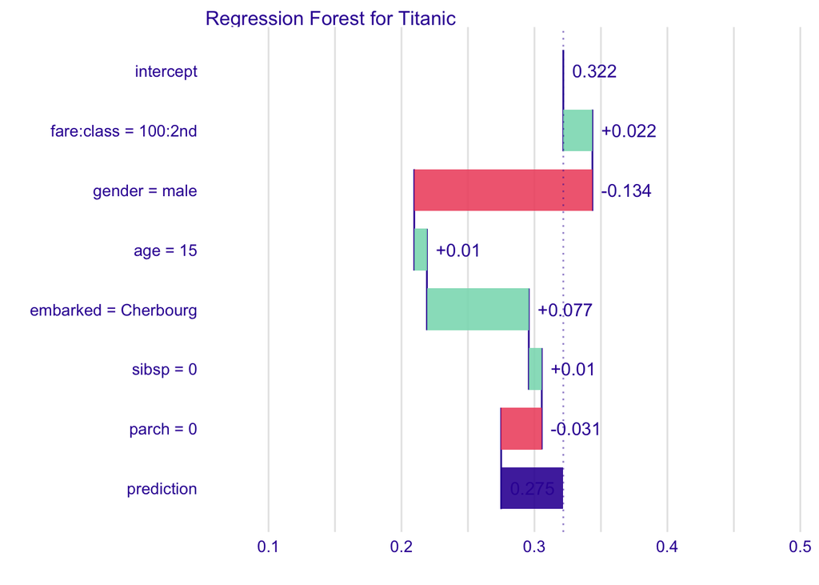

```r
plot(ibd_rf)
```

Let’s see how this interaction was identified. Here we have Break down plots with two different orderings.

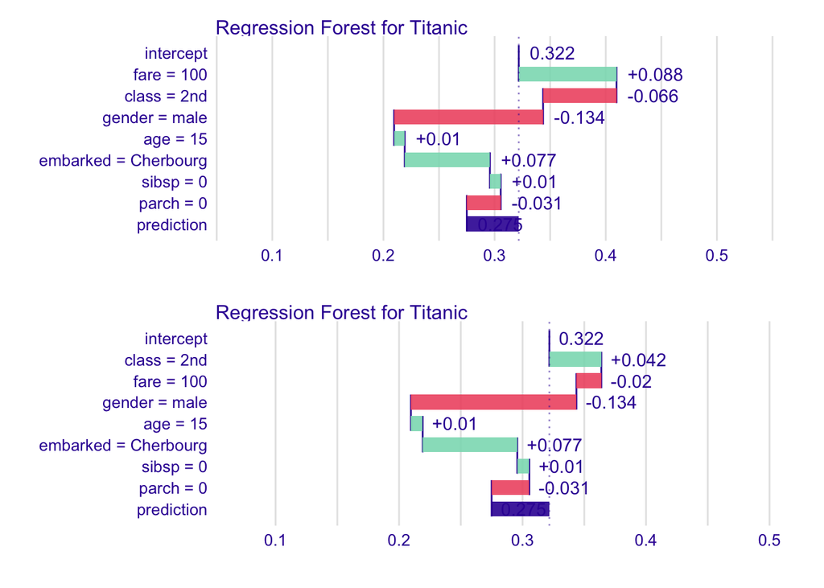

```r
library("patchwork")
bd_rf_fag <- predict_parts(titanic_ex,
                 new_observation = henry,
                 order = c("class", "fare", "gender", "age", "embarked", "sibsp", "parch"))
bd_rf_afg <- predict_parts(titanic_ex,
                 new_observation = henry,
                 order = c("fare", "class", "gender", "age", "embarked", "sibsp", "parch"))
plot(bd_rf_afg) / plot(bd_rf_fag)
```